# Risk Factor Analysis

## Outcome Variable

**Outcome Variable:** y_rate_len

## Predictor Variables

**Intervention Variable:** single

**Adjustment Set:**

unadjusted

## Stratifying Variables

The analysis was stratified on these variable(s):

- agecat
- studyid
- country

## Data Summary

| agecat | studyid | country | single | n_cell | n |
| --- | --- | --- | --- | --- | --- |
| 0-3 months | ki0047075b-MAL-ED | BANGLADESH | 0 | 244 | 244 |
| 0-3 months | ki0047075b-MAL-ED | BANGLADESH | 1 | 0 | 244 |
| 0-3 months | ki0047075b-MAL-ED | BRAZIL | 0 | 157 | 180 |
| 0-3 months | ki0047075b-MAL-ED | BRAZIL | 1 | 23 | 180 |
| 0-3 months | ki0047075b-MAL-ED | INDIA | 0 | 200 | 200 |
| 0-3 months | ki0047075b-MAL-ED | INDIA | 1 | 0 | 200 |
| 0-3 months | ki0047075b-MAL-ED | NEPAL | 0 | 175 | 175 |
| 0-3 months | ki0047075b-MAL-ED | NEPAL | 1 | 0 | 175 |
| 0-3 months | ki0047075b-MAL-ED | PERU | 0 | 238 | 271 |
| 0-3 months | ki0047075b-MAL-ED | PERU | 1 | 33 | 271 |
| 0-3 months | ki0047075b-MAL-ED | SOUTH AFRICA | 0 | 131 | 229 |
| 0-3 months | ki0047075b-MAL-ED | SOUTH AFRICA | 1 | 98 | 229 |
| 0-3 months | ki0047075b-MAL-ED | TANZANIA, UNITED REPUBLIC OF | 0 | 220 | 229 |
| 0-3 months | ki0047075b-MAL-ED | TANZANIA, UNITED REPUBLIC OF | 1 | 9 | 229 |
| 0-3 months | ki1119695-PROBIT | BELARUS | 0 | 12251 | 12745 |
| 0-3 months | ki1119695-PROBIT | BELARUS | 1 | 494 | 12745 |
| 0-3 months | ki1126311-ZVITAMBO | ZIMBABWE | 0 | 7344 | 7835 |
| 0-3 months | ki1126311-ZVITAMBO | ZIMBABWE | 1 | 491 | 7835 |
| 0-3 months | ki1135781-COHORTS | GUATEMALA | 0 | 632 | 676 |
| 0-3 months | ki1135781-COHORTS | GUATEMALA | 1 | 44 | 676 |
| 0-3 months | ki1135781-COHORTS | INDIA | 0 | 4655 | 4662 |
| 0-3 months | ki1135781-COHORTS | INDIA | 1 | 7 | 4662 |
| 3-6 months | ki0047075b-MAL-ED | BANGLADESH | 0 | 231 | 231 |
| 3-6 months | ki0047075b-MAL-ED | BANGLADESH | 1 | 0 | 231 |
| 3-6 months | ki0047075b-MAL-ED | BRAZIL | 0 | 178 | 208 |
| 3-6 months | ki0047075b-MAL-ED | BRAZIL | 1 | 30 | 208 |
| 3-6 months | ki0047075b-MAL-ED | INDIA | 0 | 227 | 227 |
| 3-6 months | ki0047075b-MAL-ED | INDIA | 1 | 0 | 227 |
| 3-6 months | ki0047075b-MAL-ED | NEPAL | 0 | 233 | 233 |
| 3-6 months | ki0047075b-MAL-ED | NEPAL | 1 | 0 | 233 |

[output cut: 70 more lines]

The following strata were considered:

- agecat: 0-3 months, studyid: ki0047075b-MAL-ED, country: BANGLADESH
- agecat: 0-3 months, studyid: ki0047075b-MAL-ED, country: BRAZIL
- agecat: 0-3 months, studyid: ki0047075b-MAL-ED, country: INDIA
- agecat: 0-3 months, studyid: ki0047075b-MAL-ED, country: NEPAL
- agecat: 0-3 months, studyid: ki0047075b-MAL-ED, country: PERU
- agecat: 0-3 months, studyid: ki0047075b-MAL-ED, country: SOUTH AFRICA
- agecat: 0-3 months, studyid: ki0047075b-MAL-ED, country: TANZANIA, UNITED REPUBLIC OF
- agecat: 0-3 months, studyid: ki1119695-PROBIT, country: BELARUS
- agecat: 0-3 months, studyid: ki1126311-ZVITAMBO, country: ZIMBABWE
- agecat: 0-3 months, studyid: ki1135781-COHORTS, country: GUATEMALA
- agecat: 0-3 months, studyid: ki1135781-COHORTS, country: INDIA
- agecat: 12-24 months, studyid: ki0047075b-MAL-ED, country: BANGLADESH
- agecat: 12-24 months, studyid: ki0047075b-MAL-ED, country: BRAZIL
- agecat: 12-24 months, studyid: ki0047075b-MAL-ED, country: INDIA
- agecat: 12-24 months, studyid: ki0047075b-MAL-ED, country: NEPAL
- agecat: 12-24 months, studyid: ki0047075b-MAL-ED, country: PERU
- agecat: 12-24 months, studyid: ki0047075b-MAL-ED, country: SOUTH AFRICA
- agecat: 12-24 months, studyid: ki0047075b-MAL-ED, country: TANZANIA, UNITED REPUBLIC OF
- agecat: 12-24 months, studyid: ki1066203-TanzaniaChild2, country: TANZANIA, UNITED REPUBLIC OF
- agecat: 12-24 months, studyid: ki1119695-PROBIT, country: BELARUS
- agecat: 12-24 months, studyid: ki1126311-ZVITAMBO, country: ZIMBABWE
- agecat: 12-24 months, studyid: ki1135781-COHORTS, country: GUATEMALA
- agecat: 12-24 months, studyid: ki1135781-COHORTS, country: INDIA
- agecat: 12-24 months, studyid: ki1135781-COHORTS, country: PHILIPPINES
- agecat: 3-6 months, studyid: ki0047075b-MAL-ED, country: BANGLADESH
- agecat: 3-6 months, studyid: ki0047075b-MAL-ED, country: BRAZIL
- agecat: 3-6 months, studyid: ki0047075b-MAL-ED, country: INDIA
- agecat: 3-6 months, studyid: ki0047075b-MAL-ED, country: NEPAL
- agecat: 3-6 months, studyid: ki0047075b-MAL-ED, country: PERU
- agecat: 3-6 months, studyid: ki0047075b-MAL-ED, country: SOUTH AFRICA
- agecat: 3-6 months, studyid: ki0047075b-MAL-ED, country: TANZANIA, UNITED REPUBLIC OF
- agecat: 3-6 months, studyid: ki1066203-TanzaniaChild2, country: TANZANIA, UNITED REPUBLIC OF
- agecat: 3-6 months, studyid: ki1119695-PROBIT, country: BELARUS
- agecat: 3-6 months, studyid: ki1126311-ZVITAMBO, country: ZIMBABWE
- agecat: 3-6 months, studyid: ki1135781-COHORTS, country: GUATEMALA
- agecat: 3-6 months, studyid: ki1135781-COHORTS, country: INDIA
- agecat: 6-12 months, studyid: ki0047075b-MAL-ED, country: BANGLADESH
- agecat: 6-12 months, studyid: ki0047075b-MAL-ED, country: BRAZIL
- agecat: 6-12 months, studyid: ki0047075b-MAL-ED, country: INDIA
- agecat: 6-12 months, studyid: ki0047075b-MAL-ED, country: NEPAL
- agecat: 6-12 months, studyid: ki0047075b-MAL-ED, country: PERU
- agecat: 6-12 months, studyid: ki0047075b-MAL-ED, country: SOUTH AFRICA
- agecat: 6-12 months, studyid: ki0047075b-MAL-ED, country: TANZANIA, UNITED REPUBLIC OF
- agecat: 6-12 months, studyid: ki1066203-TanzaniaChild2, country: TANZANIA, UNITED REPUBLIC OF
- agecat: 6-12 months, studyid: ki1112895-Guatemala BSC, country: GUATEMALA
- agecat: 6-12 months, studyid: ki1119695-PROBIT, country: BELARUS
- agecat: 6-12 months, studyid: ki1126311-ZVITAMBO, country: ZIMBABWE
- agecat: 6-12 months, studyid: ki1135781-COHORTS, country: GUATEMALA
- agecat: 6-12 months, studyid: ki1135781-COHORTS, country: INDIA
- agecat: 6-12 months, studyid: ki1135781-COHORTS, country: PHILIPPINES

### Dropped Strata

- agecat: 0-3 months, studyid: ki0047075b-MAL-ED, country: BANGLADESH
- agecat: 0-3 months, studyid: ki0047075b-MAL-ED, country: INDIA
- agecat: 0-3 months, studyid: ki0047075b-MAL-ED, country: NEPAL
- agecat: 3-6 months, studyid: ki0047075b-MAL-ED, country: BANGLADESH
- agecat: 3-6 months, studyid: ki0047075b-MAL-ED, country: INDIA
- agecat: 3-6 months, studyid: ki0047075b-MAL-ED, country: NEPAL
- agecat: 6-12 months, studyid: ki0047075b-MAL-ED, country: BANGLADESH
- agecat: 6-12 months, studyid: ki0047075b-MAL-ED, country: INDIA
- agecat: 6-12 months, studyid: ki0047075b-MAL-ED, country: NEPAL
- agecat: 12-24 months, studyid: ki0047075b-MAL-ED, country: BANGLADESH
- agecat: 12-24 months, studyid: ki0047075b-MAL-ED, country: INDIA
- agecat: 12-24 months, studyid: ki0047075b-MAL-ED, country: NEPAL
- agecat: 12-24 months, studyid: ki1066203-TanzaniaChild2, country: TANZANIA, UNITED REPUBLIC OF

## Methods Detail

We’re interested in the causal parameters $E[Y_a]$ for all values of $a \in \mathcal{A}$. These parameters represent the mean outcome if, possibly contrary to fact, we intervened to set all units to have $A=a$. Under the randomization and positivity assumptions, these are identified by the statistical parameters $\psi_a=E_W[E_{Y|A,W}(Y|A=a,W)]$. In addition, we’re interested in the mean of $Y$, $E[Y]$ under no intervention (the observed mean). We will estimate these parameters by using SuperLearner to fit the relevant likelihood factors – $E_{Y|A,W}(Y|A=a,W)$ and $p(A=a|W)$, and then updating our likelihood fit using a joint TMLE.

For unadjusted analyses ($W=\{\}$), initial likelihoods were estimated using Lrnr_glm to estimate the simple $E(Y|A)$ and Lrnr_mean to estimate $p(A)$. For adjusted analyses, a small library containing Lrnr_glmnet, Lrnr_xgboost, and Lrnr_mean was used.

# Results Detail

## Results Plots

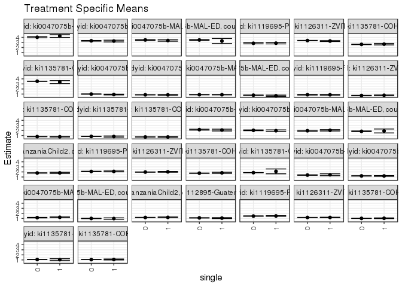

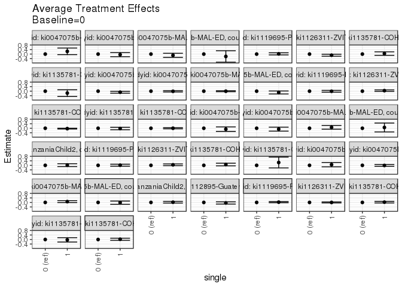

## Results Table

### Parameter: TSM

| agecat | studyid | country | intervention_level | baseline_level | estimate | ci_lower | ci_upper |
| --- | --- | --- | --- | --- | --- | --- | --- |
| 0-3 months | ki0047075b-MAL-ED | BRAZIL | 0 | NA | 4.0201616 | 3.9114235 | 4.1288997 |
| 0-3 months | ki0047075b-MAL-ED | BRAZIL | 1 | NA | 4.2612818 | 3.9886007 | 4.5339630 |
| 0-3 months | ki0047075b-MAL-ED | PERU | 0 | NA | 3.3217553 | 3.2538255 | 3.3896851 |
| 0-3 months | ki0047075b-MAL-ED | PERU | 1 | NA | 3.2733462 | 3.1023443 | 3.4443481 |
| 0-3 months | ki0047075b-MAL-ED | SOUTH AFRICA | 0 | NA | 3.4918943 | 3.3766621 | 3.6071264 |
| 0-3 months | ki0047075b-MAL-ED | SOUTH AFRICA | 1 | NA | 3.3827492 | 3.2430150 | 3.5224835 |
| 0-3 months | ki0047075b-MAL-ED | TANZANIA, UNITED REPUBLIC OF | 0 | NA | 3.4898998 | 3.4123983 | 3.5674013 |
| 0-3 months | ki0047075b-MAL-ED | TANZANIA, UNITED REPUBLIC OF | 1 | NA | 3.2810147 | 2.7797690 | 3.7822603 |
| 0-3 months | ki1119695-PROBIT | BELARUS | 0 | NA | 2.8348123 | 2.7210155 | 2.9486091 |
| 0-3 months | ki1119695-PROBIT | BELARUS | 1 | NA | 2.8544612 | 2.7112158 | 2.9977065 |
| 0-3 months | ki1126311-ZVITAMBO | ZIMBABWE | 0 | NA | 3.3780054 | 3.3564844 | 3.3995263 |
| 0-3 months | ki1126311-ZVITAMBO | ZIMBABWE | 1 | NA | 3.2774420 | 3.1912970 | 3.3635869 |
| 0-3 months | ki1135781-COHORTS | GUATEMALA | 0 | NA | 2.6170390 | 2.5696552 | 2.6644229 |
| 0-3 months | ki1135781-COHORTS | GUATEMALA | 1 | NA | 2.6599514 | 2.5126696 | 2.8072333 |
| 0-3 months | ki1135781-COHORTS | INDIA | 0 | NA | 3.5325772 | 3.5156995 | 3.5494548 |
| 0-3 months | ki1135781-COHORTS | INDIA | 1 | NA | 3.3603211 | 3.0644026 | 3.6562397 |
| 3-6 months | ki0047075b-MAL-ED | BRAZIL | 0 | NA | 2.1594503 | 2.0719289 | 2.2469716 |
| 3-6 months | ki0047075b-MAL-ED | BRAZIL | 1 | NA | 2.0787831 | 1.9027213 | 2.2548449 |
| 3-6 months | ki0047075b-MAL-ED | PERU | 0 | NA | 2.0275835 | 1.9563119 | 2.0988551 |
| 3-6 months | ki0047075b-MAL-ED | PERU | 1 | NA | 1.9503020 | 1.7884046 | 2.1121995 |
| 3-6 months | ki0047075b-MAL-ED | SOUTH AFRICA | 0 | NA | 1.9443512 | 1.8436217 | 2.0450807 |
| 3-6 months | ki0047075b-MAL-ED | SOUTH AFRICA | 1 | NA | 2.0265654 | 1.8953829 | 2.1577479 |
| 3-6 months | ki0047075b-MAL-ED | TANZANIA, UNITED REPUBLIC OF | 0 | NA | 1.8277484 | 1.7588679 | 1.8966290 |
| 3-6 months | ki0047075b-MAL-ED | TANZANIA, UNITED REPUBLIC OF | 1 | NA | 1.8977087 | 1.5100436 | 2.2853737 |
| 3-6 months | ki1066203-TanzaniaChild2 | TANZANIA, UNITED REPUBLIC OF | 0 | NA | 1.7909052 | 1.7532819 | 1.8285286 |
| 3-6 months | ki1066203-TanzaniaChild2 | TANZANIA, UNITED REPUBLIC OF | 1 | NA | 1.8087200 | 1.6895827 | 1.9278573 |
| 3-6 months | ki1119695-PROBIT | BELARUS | 0 | NA | 2.0910131 | 2.0493748 | 2.1326514 |
| 3-6 months | ki1119695-PROBIT | BELARUS | 1 | NA | 2.1027613 | 2.0110207 | 2.1945018 |
| 3-6 months | ki1126311-ZVITAMBO | ZIMBABWE | 0 | NA | 1.9722005 | 1.9514692 | 1.9929318 |
| 3-6 months | ki1126311-ZVITAMBO | ZIMBABWE | 1 | NA | 2.0188899 | 1.9439913 | 2.0937884 |
| 3-6 months | ki1135781-COHORTS | GUATEMALA | 0 | NA | 1.7492401 | 1.7163974 | 1.7820828 |
| 3-6 months | ki1135781-COHORTS | GUATEMALA | 1 | NA | 1.8199604 | 1.7049608 | 1.9349600 |
| 3-6 months | ki1135781-COHORTS | INDIA | 0 | NA | 1.8568411 | 1.8428475 | 1.8708347 |
| 3-6 months | ki1135781-COHORTS | INDIA | 1 | NA | 2.1076789 | 1.6292852 | 2.5860727 |
| 6-12 months | ki0047075b-MAL-ED | BRAZIL | 0 | NA | 1.3778779 | 1.3333254 | 1.4224304 |
| 6-12 months | ki0047075b-MAL-ED | BRAZIL | 1 | NA | 1.4387256 | 1.2531347 | 1.6243166 |
| 6-12 months | ki0047075b-MAL-ED | PERU | 0 | NA | 1.2114582 | 1.1756025 | 1.2473139 |
| 6-12 months | ki0047075b-MAL-ED | PERU | 1 | NA | 1.2014333 | 1.1283884 | 1.2744781 |
| 6-12 months | ki0047075b-MAL-ED | SOUTH AFRICA | 0 | NA | 1.1579112 | 1.1058257 | 1.2099967 |
| 6-12 months | ki0047075b-MAL-ED | SOUTH AFRICA | 1 | NA | 1.2291229 | 1.1640707 | 1.2941752 |
| 6-12 months | ki0047075b-MAL-ED | TANZANIA, UNITED REPUBLIC OF | 0 | NA | 1.0025137 | 0.9645841 | 1.0404432 |
| 6-12 months | ki0047075b-MAL-ED | TANZANIA, UNITED REPUBLIC OF | 1 | NA | 0.9816515 | 0.8444604 | 1.1188425 |
| 6-12 months | ki1066203-TanzaniaChild2 | TANZANIA, UNITED REPUBLIC OF | 0 | NA | 1.1951897 | 1.1725650 | 1.2178143 |
| 6-12 months | ki1066203-TanzaniaChild2 | TANZANIA, UNITED REPUBLIC OF | 1 | NA | 1.2136688 | 1.1412039 | 1.2861337 |
| 6-12 months | ki1112895-Guatemala BSC | GUATEMALA | 0 | NA | 1.1128985 | 1.0800142 | 1.1457827 |
| 6-12 months | ki1112895-Guatemala BSC | GUATEMALA | 1 | NA | 1.0671848 | 0.9735203 | 1.1608492 |
| 6-12 months | ki1119695-PROBIT | BELARUS | 0 | NA | 1.4700482 | 1.4316571 | 1.5084393 |
| 6-12 months | ki1119695-PROBIT | BELARUS | 1 | NA | 1.4925044 | 1.4320962 | 1.5529125 |
| 6-12 months | ki1126311-ZVITAMBO | ZIMBABWE | 0 | NA | 1.1981508 | 1.1868385 | 1.2094631 |
| 6-12 months | ki1126311-ZVITAMBO | ZIMBABWE | 1 | NA | 1.1970032 | 1.1534301 | 1.2405763 |
| 6-12 months | ki1135781-COHORTS | GUATEMALA | 0 | NA | 1.0138510 | 0.9953347 | 1.0323673 |
| 6-12 months | ki1135781-COHORTS | GUATEMALA | 1 | NA | 1.0369557 | 0.9667511 | 1.1071603 |
| 6-12 months | ki1135781-COHORTS | INDIA | 0 | NA | 1.0834574 | 1.0737861 | 1.0931287 |
| 6-12 months | ki1135781-COHORTS | INDIA | 1 | NA | 1.0528858 | 0.8631844 | 1.2425872 |
| 6-12 months | ki1135781-COHORTS | PHILIPPINES | 0 | NA | 1.0664611 | 1.0541234 | 1.0787988 |
| 6-12 months | ki1135781-COHORTS | PHILIPPINES | 1 | NA | 1.0869744 | 0.9936884 | 1.1802604 |
| 12-24 months | ki0047075b-MAL-ED | BRAZIL | 0 | NA | 0.9936186 | 0.9606721 | 1.0265652 |
| 12-24 months | ki0047075b-MAL-ED | BRAZIL | 1 | NA | 0.8993787 | 0.8225626 | 0.9761949 |
| 12-24 months | ki0047075b-MAL-ED | PERU | 0 | NA | 0.8477637 | 0.8255142 | 0.8700132 |
| 12-24 months | ki0047075b-MAL-ED | PERU | 1 | NA | 0.8359849 | 0.7801558 | 0.8918139 |
| 12-24 months | ki0047075b-MAL-ED | SOUTH AFRICA | 0 | NA | 0.8716063 | 0.8423291 | 0.9008834 |
| 12-24 months | ki0047075b-MAL-ED | SOUTH AFRICA | 1 | NA | 0.8677734 | 0.8332007 | 0.9023460 |
| 12-24 months | ki0047075b-MAL-ED | TANZANIA, UNITED REPUBLIC OF | 0 | NA | 0.7696914 | 0.7460211 | 0.7933617 |
| 12-24 months | ki0047075b-MAL-ED | TANZANIA, UNITED REPUBLIC OF | 1 | NA | 0.6530710 | 0.5222737 | 0.7838682 |
| 12-24 months | ki1119695-PROBIT | BELARUS | 0 | NA | 0.8604486 | 0.8058412 | 0.9150560 |
| 12-24 months | ki1119695-PROBIT | BELARUS | 1 | NA | 0.8509511 | 0.7865052 | 0.9153969 |
| 12-24 months | ki1126311-ZVITAMBO | ZIMBABWE | 0 | NA | 0.7054387 | 0.6775140 | 0.7333634 |
| 12-24 months | ki1126311-ZVITAMBO | ZIMBABWE | 1 | NA | 0.7521830 | 0.6940658 | 0.8103002 |
| 12-24 months | ki1135781-COHORTS | GUATEMALA | 0 | NA | 0.7820505 | 0.7703852 | 0.7937158 |
| 12-24 months | ki1135781-COHORTS | GUATEMALA | 1 | NA | 0.7481337 | 0.7132521 | 0.7830153 |
| 12-24 months | ki1135781-COHORTS | INDIA | 0 | NA | 0.8192639 | 0.8133693 | 0.8251585 |
| 12-24 months | ki1135781-COHORTS | INDIA | 1 | NA | 0.7967763 | 0.6880851 | 0.9054674 |
| 12-24 months | ki1135781-COHORTS | PHILIPPINES | 0 | NA | 0.7055460 | 0.6980855 | 0.7130065 |
| 12-24 months | ki1135781-COHORTS | PHILIPPINES | 1 | NA | 0.7064456 | 0.6547606 | 0.7581307 |

### Parameter: E(Y)

| agecat | studyid | country | intervention_level | baseline_level | estimate | ci_lower | ci_upper |
| --- | --- | --- | --- | --- | --- | --- | --- |
| 0-3 months | ki0047075b-MAL-ED | BRAZIL | NA | NA | 4.0509714 | 3.9492443 | 4.1526985 |
| 0-3 months | ki0047075b-MAL-ED | PERU | NA | NA | 3.3158605 | 3.2526447 | 3.3790763 |
| 0-3 months | ki0047075b-MAL-ED | SOUTH AFRICA | NA | NA | 3.4451859 | 3.3559092 | 3.5344627 |
| 0-3 months | ki0047075b-MAL-ED | TANZANIA, UNITED REPUBLIC OF | NA | NA | 3.4816904 | 3.4044928 | 3.5588880 |
| 0-3 months | ki1119695-PROBIT | BELARUS | NA | NA | 2.8355739 | 2.7218468 | 2.9493011 |
| 0-3 months | ki1126311-ZVITAMBO | ZIMBABWE | NA | NA | 3.3717033 | 3.3508142 | 3.3925924 |
| 0-3 months | ki1135781-COHORTS | GUATEMALA | NA | NA | 2.6198322 | 2.5745000 | 2.6651643 |
| 0-3 months | ki1135781-COHORTS | INDIA | NA | NA | 3.5323185 | 3.5154593 | 3.5491778 |
| 3-6 months | ki0047075b-MAL-ED | BRAZIL | NA | NA | 2.1478156 | 2.0686357 | 2.2269955 |
| 3-6 months | ki0047075b-MAL-ED | PERU | NA | NA | 2.0183213 | 1.9525900 | 2.0840526 |
| 3-6 months | ki0047075b-MAL-ED | SOUTH AFRICA | NA | NA | 1.9811941 | 1.9001209 | 2.0622672 |
| 3-6 months | ki0047075b-MAL-ED | TANZANIA, UNITED REPUBLIC OF | NA | NA | 1.8300902 | 1.7622436 | 1.8979368 |
| 3-6 months | ki1066203-TanzaniaChild2 | TANZANIA, UNITED REPUBLIC OF | NA | NA | 1.7925022 | 1.7566242 | 1.8283801 |
| 3-6 months | ki1119695-PROBIT | BELARUS | NA | NA | 2.0914863 | 2.0503474 | 2.1326251 |
| 3-6 months | ki1126311-ZVITAMBO | ZIMBABWE | NA | NA | 1.9751041 | 1.9551098 | 1.9950984 |
| 3-6 months | ki1135781-COHORTS | GUATEMALA | NA | NA | 1.7546801 | 1.7230708 | 1.7862894 |
| 3-6 months | ki1135781-COHORTS | INDIA | NA | NA | 1.8572663 | 1.8432699 | 1.8712628 |
| 6-12 months | ki0047075b-MAL-ED | BRAZIL | NA | NA | 1.3863464 | 1.3400121 | 1.4326807 |
| 6-12 months | ki0047075b-MAL-ED | PERU | NA | NA | 1.2102315 | 1.1775158 | 1.2429472 |
| 6-12 months | ki0047075b-MAL-ED | SOUTH AFRICA | NA | NA | 1.1895267 | 1.1483723 | 1.2306812 |
| 6-12 months | ki0047075b-MAL-ED | TANZANIA, UNITED REPUBLIC OF | NA | NA | 1.0019524 | 0.9648566 | 1.0390481 |
| 6-12 months | ki1066203-TanzaniaChild2 | TANZANIA, UNITED REPUBLIC OF | NA | NA | 1.1968182 | 1.1752193 | 1.2184170 |
| 6-12 months | ki1112895-Guatemala BSC | GUATEMALA | NA | NA | 1.1080731 | 1.0769747 | 1.1391716 |
| 6-12 months | ki1119695-PROBIT | BELARUS | NA | NA | 1.4709224 | 1.4326640 | 1.5091808 |
| 6-12 months | ki1126311-ZVITAMBO | ZIMBABWE | NA | NA | 1.1980807 | 1.1871310 | 1.2090305 |
| 6-12 months | ki1135781-COHORTS | GUATEMALA | NA | NA | 1.0157051 | 0.9977618 | 1.0336483 |
| 6-12 months | ki1135781-COHORTS | INDIA | NA | NA | 1.0833934 | 1.0737340 | 1.0930527 |
| 6-12 months | ki1135781-COHORTS | PHILIPPINES | NA | NA | 1.0669587 | 1.0547088 | 1.0792086 |
| 12-24 months | ki0047075b-MAL-ED | BRAZIL | NA | NA | 0.9816245 | 0.9508764 | 1.0123725 |
| 12-24 months | ki0047075b-MAL-ED | PERU | NA | NA | 0.8463453 | 0.8256453 | 0.8670453 |
| 12-24 months | ki0047075b-MAL-ED | SOUTH AFRICA | NA | NA | 0.8699064 | 0.8475321 | 0.8922808 |
| 12-24 months | ki0047075b-MAL-ED | TANZANIA, UNITED REPUBLIC OF | NA | NA | 0.7663111 | 0.7428636 | 0.7897586 |
| 12-24 months | ki1119695-PROBIT | BELARUS | NA | NA | 0.8601486 | 0.8069287 | 0.9133686 |
| 12-24 months | ki1126311-ZVITAMBO | ZIMBABWE | NA | NA | 0.7099126 | 0.6840087 | 0.7358165 |
| 12-24 months | ki1135781-COHORTS | GUATEMALA | NA | NA | 0.7791030 | 0.7680096 | 0.7901963 |
| 12-24 months | ki1135781-COHORTS | INDIA | NA | NA | 0.8192072 | 0.8133209 | 0.8250935 |
| 12-24 months | ki1135781-COHORTS | PHILIPPINES | NA | NA | 0.7055690 | 0.6981801 | 0.7129578 |

### Parameter: ATE

| agecat | studyid | country | intervention_level | baseline_level | estimate | ci_lower | ci_upper |
| --- | --- | --- | --- | --- | --- | --- | --- |
| 0-3 months | ki0047075b-MAL-ED | BRAZIL | 0 | 0 | 0.0000000 | 0.0000000 | 0.0000000 |
| 0-3 months | ki0047075b-MAL-ED | BRAZIL | 1 | 0 | 0.2411202 | -0.0524423 | 0.5346828 |
| 0-3 months | ki0047075b-MAL-ED | PERU | 0 | 0 | 0.0000000 | 0.0000000 | 0.0000000 |
| 0-3 months | ki0047075b-MAL-ED | PERU | 1 | 0 | -0.0484091 | -0.2324094 | 0.1355911 |
| 0-3 months | ki0047075b-MAL-ED | SOUTH AFRICA | 0 | 0 | 0.0000000 | 0.0000000 | 0.0000000 |
| 0-3 months | ki0047075b-MAL-ED | SOUTH AFRICA | 1 | 0 | -0.1091450 | -0.2902640 | 0.0719740 |
| 0-3 months | ki0047075b-MAL-ED | TANZANIA, UNITED REPUBLIC OF | 0 | 0 | 0.0000000 | 0.0000000 | 0.0000000 |
| 0-3 months | ki0047075b-MAL-ED | TANZANIA, UNITED REPUBLIC OF | 1 | 0 | -0.2088852 | -0.7160870 | 0.2983167 |
| 0-3 months | ki1119695-PROBIT | BELARUS | 0 | 0 | 0.0000000 | 0.0000000 | 0.0000000 |
| 0-3 months | ki1119695-PROBIT | BELARUS | 1 | 0 | 0.0196488 | -0.0722667 | 0.1115644 |
| 0-3 months | ki1126311-ZVITAMBO | ZIMBABWE | 0 | 0 | 0.0000000 | 0.0000000 | 0.0000000 |
| 0-3 months | ki1126311-ZVITAMBO | ZIMBABWE | 1 | 0 | -0.1005634 | -0.1893559 | -0.0117709 |
| 0-3 months | ki1135781-COHORTS | GUATEMALA | 0 | 0 | 0.0000000 | 0.0000000 | 0.0000000 |
| 0-3 months | ki1135781-COHORTS | GUATEMALA | 1 | 0 | 0.0429124 | -0.1118041 | 0.1976288 |
| 0-3 months | ki1135781-COHORTS | INDIA | 0 | 0 | 0.0000000 | 0.0000000 | 0.0000000 |
| 0-3 months | ki1135781-COHORTS | INDIA | 1 | 0 | -0.1722560 | -0.4686555 | 0.1241434 |
| 3-6 months | ki0047075b-MAL-ED | BRAZIL | 0 | 0 | 0.0000000 | 0.0000000 | 0.0000000 |
| 3-6 months | ki0047075b-MAL-ED | BRAZIL | 1 | 0 | -0.0806672 | -0.2772828 | 0.1159485 |
| 3-6 months | ki0047075b-MAL-ED | PERU | 0 | 0 | 0.0000000 | 0.0000000 | 0.0000000 |
| 3-6 months | ki0047075b-MAL-ED | PERU | 1 | 0 | -0.0772814 | -0.2541724 | 0.0996096 |
| 3-6 months | ki0047075b-MAL-ED | SOUTH AFRICA | 0 | 0 | 0.0000000 | 0.0000000 | 0.0000000 |
| 3-6 months | ki0047075b-MAL-ED | SOUTH AFRICA | 1 | 0 | 0.0822142 | -0.0831801 | 0.2476085 |
| 3-6 months | ki0047075b-MAL-ED | TANZANIA, UNITED REPUBLIC OF | 0 | 0 | 0.0000000 | 0.0000000 | 0.0000000 |
| 3-6 months | ki0047075b-MAL-ED | TANZANIA, UNITED REPUBLIC OF | 1 | 0 | 0.0699602 | -0.3237767 | 0.4636971 |
| 3-6 months | ki1066203-TanzaniaChild2 | TANZANIA, UNITED REPUBLIC OF | 0 | 0 | 0.0000000 | 0.0000000 | 0.0000000 |
| 3-6 months | ki1066203-TanzaniaChild2 | TANZANIA, UNITED REPUBLIC OF | 1 | 0 | 0.0178147 | -0.1071221 | 0.1427516 |
| 3-6 months | ki1119695-PROBIT | BELARUS | 0 | 0 | 0.0000000 | 0.0000000 | 0.0000000 |
| 3-6 months | ki1119695-PROBIT | BELARUS | 1 | 0 | 0.0117481 | -0.0779138 | 0.1014100 |
| 3-6 months | ki1126311-ZVITAMBO | ZIMBABWE | 0 | 0 | 0.0000000 | 0.0000000 | 0.0000000 |
| 3-6 months | ki1126311-ZVITAMBO | ZIMBABWE | 1 | 0 | 0.0466894 | -0.0310253 | 0.1244041 |
| 3-6 months | ki1135781-COHORTS | GUATEMALA | 0 | 0 | 0.0000000 | 0.0000000 | 0.0000000 |
| 3-6 months | ki1135781-COHORTS | GUATEMALA | 1 | 0 | 0.0707203 | -0.0488772 | 0.1903178 |
| 3-6 months | ki1135781-COHORTS | INDIA | 0 | 0 | 0.0000000 | 0.0000000 | 0.0000000 |
| 3-6 months | ki1135781-COHORTS | INDIA | 1 | 0 | 0.2508378 | -0.2277605 | 0.7294362 |
| 6-12 months | ki0047075b-MAL-ED | BRAZIL | 0 | 0 | 0.0000000 | 0.0000000 | 0.0000000 |
| 6-12 months | ki0047075b-MAL-ED | BRAZIL | 1 | 0 | 0.0608477 | -0.1300159 | 0.2517113 |
| 6-12 months | ki0047075b-MAL-ED | PERU | 0 | 0 | 0.0000000 | 0.0000000 | 0.0000000 |
| 6-12 months | ki0047075b-MAL-ED | PERU | 1 | 0 | -0.0100249 | -0.0913956 | 0.0713457 |
| 6-12 months | ki0047075b-MAL-ED | SOUTH AFRICA | 0 | 0 | 0.0000000 | 0.0000000 | 0.0000000 |
| 6-12 months | ki0047075b-MAL-ED | SOUTH AFRICA | 1 | 0 | 0.0712118 | -0.0121230 | 0.1545466 |
| 6-12 months | ki0047075b-MAL-ED | TANZANIA, UNITED REPUBLIC OF | 0 | 0 | 0.0000000 | 0.0000000 | 0.0000000 |
| 6-12 months | ki0047075b-MAL-ED | TANZANIA, UNITED REPUBLIC OF | 1 | 0 | -0.0208622 | -0.1631999 | 0.1214755 |
| 6-12 months | ki1066203-TanzaniaChild2 | TANZANIA, UNITED REPUBLIC OF | 0 | 0 | 0.0000000 | 0.0000000 | 0.0000000 |
| 6-12 months | ki1066203-TanzaniaChild2 | TANZANIA, UNITED REPUBLIC OF | 1 | 0 | 0.0184791 | -0.0574356 | 0.0943938 |
| 6-12 months | ki1112895-Guatemala BSC | GUATEMALA | 0 | 0 | 0.0000000 | 0.0000000 | 0.0000000 |
| 6-12 months | ki1112895-Guatemala BSC | GUATEMALA | 1 | 0 | -0.0457137 | -0.1449830 | 0.0535556 |
| 6-12 months | ki1119695-PROBIT | BELARUS | 0 | 0 | 0.0000000 | 0.0000000 | 0.0000000 |
| 6-12 months | ki1119695-PROBIT | BELARUS | 1 | 0 | 0.0224561 | -0.0269331 | 0.0718453 |
| 6-12 months | ki1126311-ZVITAMBO | ZIMBABWE | 0 | 0 | 0.0000000 | 0.0000000 | 0.0000000 |
| 6-12 months | ki1126311-ZVITAMBO | ZIMBABWE | 1 | 0 | -0.0011476 | -0.0461652 | 0.0438700 |
| 6-12 months | ki1135781-COHORTS | GUATEMALA | 0 | 0 | 0.0000000 | 0.0000000 | 0.0000000 |
| 6-12 months | ki1135781-COHORTS | GUATEMALA | 1 | 0 | 0.0231047 | -0.0495006 | 0.0957100 |
| 6-12 months | ki1135781-COHORTS | INDIA | 0 | 0 | 0.0000000 | 0.0000000 | 0.0000000 |
| 6-12 months | ki1135781-COHORTS | INDIA | 1 | 0 | -0.0305716 | -0.2205194 | 0.1593762 |
| 6-12 months | ki1135781-COHORTS | PHILIPPINES | 0 | 0 | 0.0000000 | 0.0000000 | 0.0000000 |
| 6-12 months | ki1135781-COHORTS | PHILIPPINES | 1 | 0 | 0.0205133 | -0.0735850 | 0.1146117 |
| 12-24 months | ki0047075b-MAL-ED | BRAZIL | 0 | 0 | 0.0000000 | 0.0000000 | 0.0000000 |
| 12-24 months | ki0047075b-MAL-ED | BRAZIL | 1 | 0 | -0.0942399 | -0.1778234 | -0.0106564 |
| 12-24 months | ki0047075b-MAL-ED | PERU | 0 | 0 | 0.0000000 | 0.0000000 | 0.0000000 |
| 12-24 months | ki0047075b-MAL-ED | PERU | 1 | 0 | -0.0117788 | -0.0718781 | 0.0483205 |
| 12-24 months | ki0047075b-MAL-ED | SOUTH AFRICA | 0 | 0 | 0.0000000 | 0.0000000 | 0.0000000 |
| 12-24 months | ki0047075b-MAL-ED | SOUTH AFRICA | 1 | 0 | -0.0038329 | -0.0491365 | 0.0414707 |
| 12-24 months | ki0047075b-MAL-ED | TANZANIA, UNITED REPUBLIC OF | 0 | 0 | 0.0000000 | 0.0000000 | 0.0000000 |
| 12-24 months | ki0047075b-MAL-ED | TANZANIA, UNITED REPUBLIC OF | 1 | 0 | -0.1166205 | -0.2495422 | 0.0163013 |
| 12-24 months | ki1119695-PROBIT | BELARUS | 0 | 0 | 0.0000000 | 0.0000000 | 0.0000000 |
| 12-24 months | ki1119695-PROBIT | BELARUS | 1 | 0 | -0.0094976 | -0.0875073 | 0.0685122 |
| 12-24 months | ki1126311-ZVITAMBO | ZIMBABWE | 0 | 0 | 0.0000000 | 0.0000000 | 0.0000000 |
| 12-24 months | ki1126311-ZVITAMBO | ZIMBABWE | 1 | 0 | 0.0467443 | -0.0177336 | 0.1112222 |
| 12-24 months | ki1135781-COHORTS | GUATEMALA | 0 | 0 | 0.0000000 | 0.0000000 | 0.0000000 |
| 12-24 months | ki1135781-COHORTS | GUATEMALA | 1 | 0 | -0.0339168 | -0.0706973 | 0.0028637 |
| 12-24 months | ki1135781-COHORTS | INDIA | 0 | 0 | 0.0000000 | 0.0000000 | 0.0000000 |
| 12-24 months | ki1135781-COHORTS | INDIA | 1 | 0 | -0.0224877 | -0.1313386 | 0.0863632 |
| 12-24 months | ki1135781-COHORTS | PHILIPPINES | 0 | 0 | 0.0000000 | 0.0000000 | 0.0000000 |
| 12-24 months | ki1135781-COHORTS | PHILIPPINES | 1 | 0 | 0.0008996 | -0.0513211 | 0.0531204 |